# Презентация по лабораторной работе №7

Дисциплина: операционные системы

Лобанова П. И.

Российский университет дружбы народов, Москва, Россия

22.03.2023

# Информация

## Докладчик

- Лобанова Полина Иннокентьевна
- учащаяся факультета физико-математических и естественных наук
- учащаяся направления “Математика и механика”
- Российский университет дружбы народов
- polla-2004@mail.ru

# Цель работы

Освоение основных возможностей командной оболочки Midnight Commander. Приобретение навыков практической работы по просмотру каталогов и файлов; манипуляций с ними.

# Ход работы

## Командная оболочка mc

Командная оболочка — интерфейс взаимодействия пользователя с операционной системой и программным обеспечением посредством команд. Midnight Commander (или mc) — псевдографическая командная оболочка для UNIX/Linux систем.

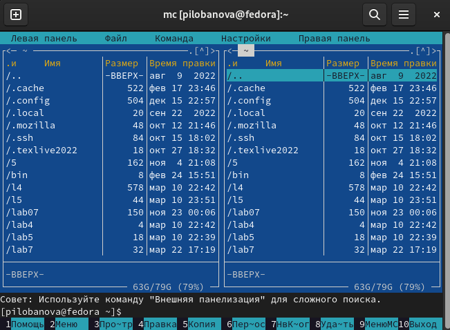

*Midnight Commander.*

## Функциональные клавиши

Функциональные клавиши позволяют копировать, перемещать, просматривать и редактировать файлы, а также создавать каталоги и переносить в них любые файлы.

[figure not shown]

*Функциональные клавиши.*

## Левая и правая панели меню

Левая (или правая) панель меню позволяет просматривать список файлов, сортировать их, а также просматривать полную информацию о файлах и каталогах.

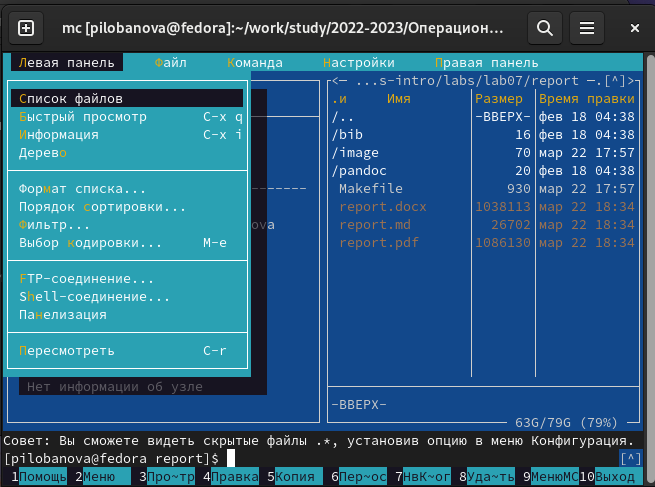

*Левая и правая панели меню.*

## Меню Файл

Меню Файл позволяет выполнять множество операций над файлами, такие как просмотр, правка, создание ссылок, переименование и перемещение.

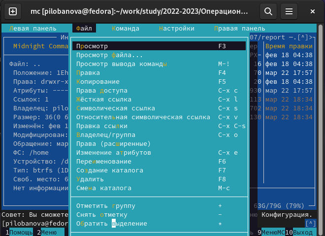

*Меню Файл.*

## Меню Команда

Меню Команда позволяет изменять панели, просматривать дерево каталогов, сравнивать каталоги и тд.

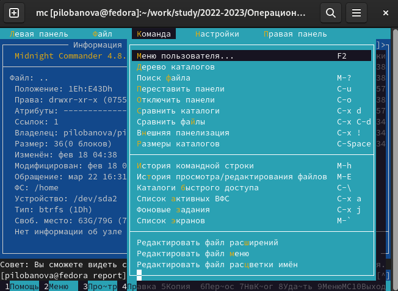

*Меню Команда.*

## Меню Настройки

Меню Настройки позволяет изменять и настраивать панели.

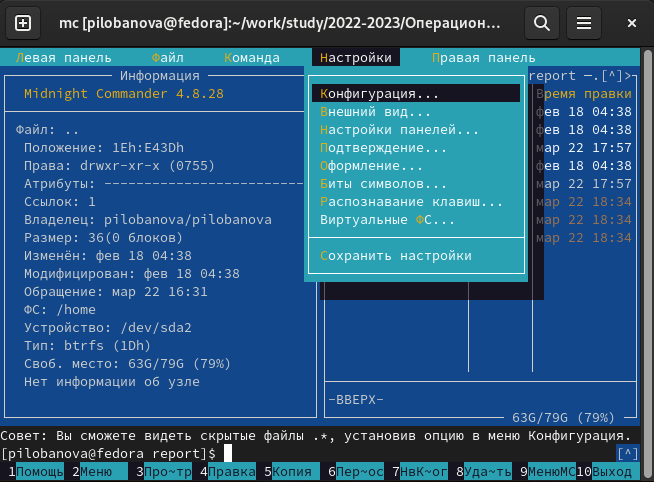

*Меню Настройки.*

## Редактор mc

С помощью редактора mc можно просматривать и изменять файлы, используя разные клавиши для удобного редактирования.

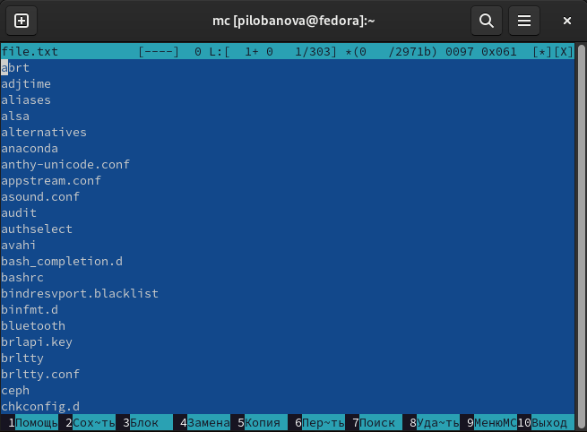

*Редактор mc.*

# Контрольные вопросы

1. Какие режимы работы есть в mc. Охарактеризуйте их.
2. Какие операции с файлами можно выполнить как с помощью команд shell, так и с помощью меню (комбинаций клавиш) mc? Приведите несколько примеров.
3. Опишите структура меню левой (или правой) панели mc, дайте характеристику командам.
4. Опишите структура меню Файл mc, дайте характеристику командам.
5. Опишите структура меню Команда mc, дайте характеристику командам.
6. Опишите структура меню Настройки mc, дайте характеристику командам.
7. Назовите и дайте характеристику встроенным командам mc.
8. Назовите и дайте характеристику командам встроенного редактора mc.
9. Дайте характеристику средствам mc, которые позволяют создавать меню, определяемые пользователем.
10. Дайте характеристику средствам mc, которые позволяют выполнять действия, определяемые пользователем, над текущим файлом.

# Вывод

Я освоила основные возможности командной оболочки Midnight Commander, а также приобрела навыки практической работы по просмотру каталогов и файлов и манипуляций с ними.